# project 1 rough draft

Will

9/26/2019

Urban Ministries has been helping those in need in our local community for over 30 years.  
They have been keeping track of some of their clients’ date throughout that time, and hopefully we can work together to gather some helpful information from this data.

One area in particular that I believe could be helpful is to look more at client-centered data, and to see if there are any noticeable patterns.

After tidying the data and clearing up typos, I first look into how long different clients received assistance for.

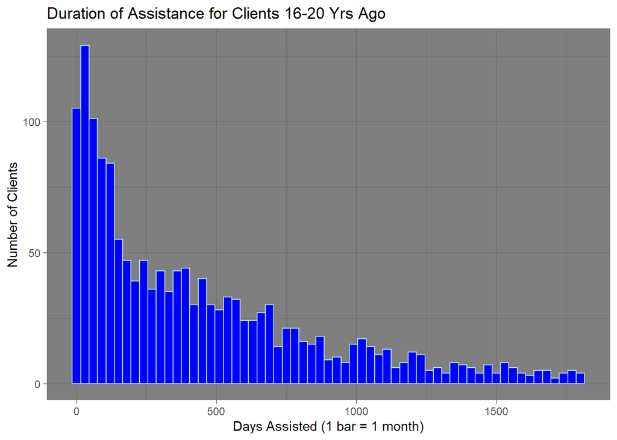

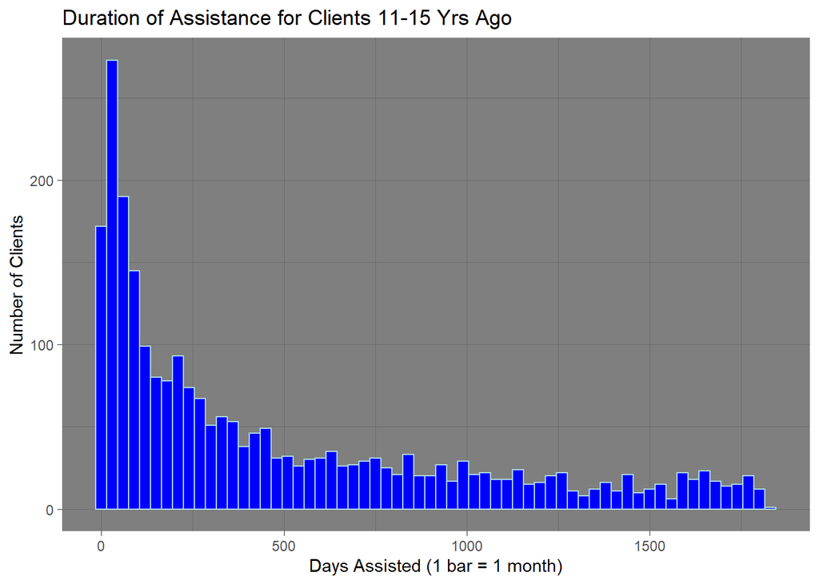

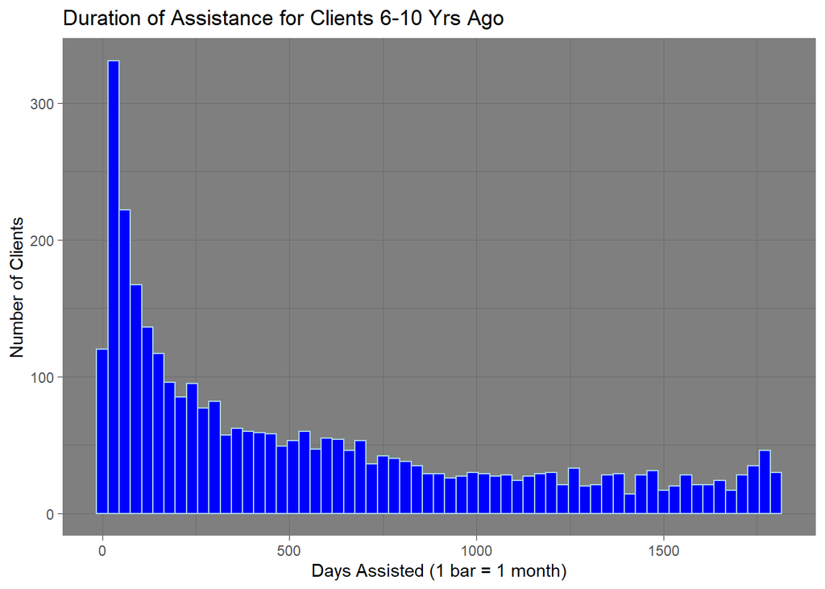

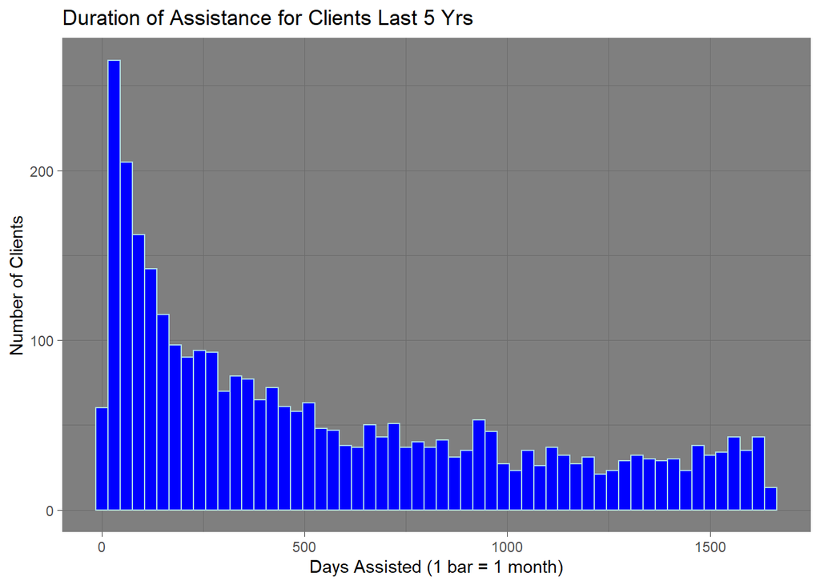

In these histograms, each bar represents 30 days, which should be an intuitive period of time for our needs.

Some things I notice most obviously are: -The spike at the second month means a large proportion of people receive assistance for only about 2 months. -The first month initially is relatively high but has been decreasing over the years, so there may be fewer people who receive only short-term help during the past five years. Are there now more people receiving long-term help than before? -Frequencies taper off quite quickly after the first few months -It could be possible to divide the durations into discrete categories.

Splitting the durations of assistance up into several categories, we can see a more specific breakdown of how long clients have been receiving help from Urban Ministries:

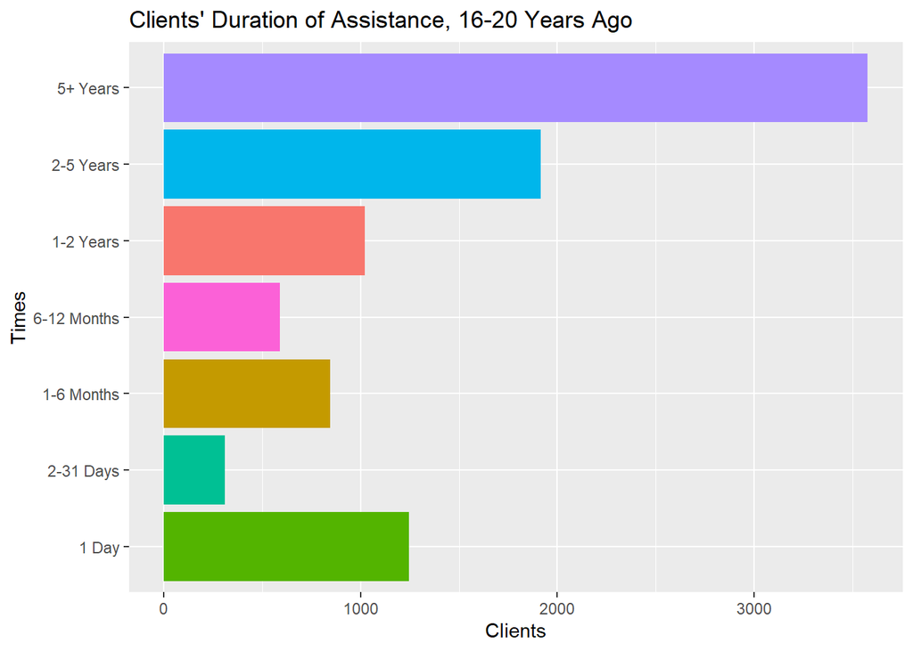

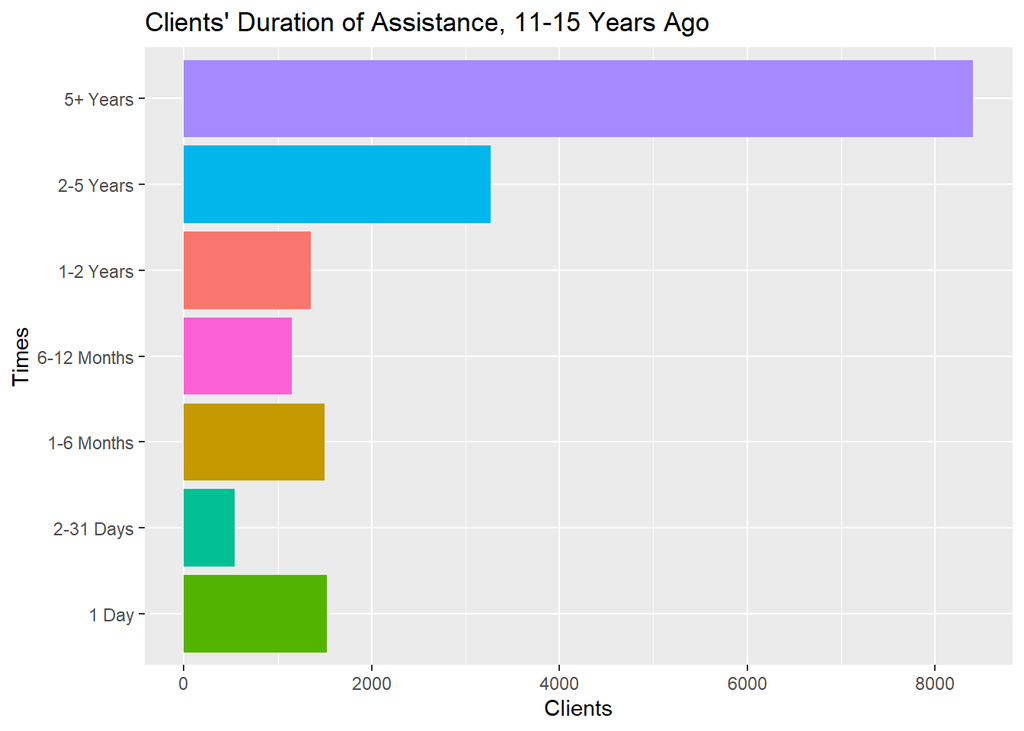

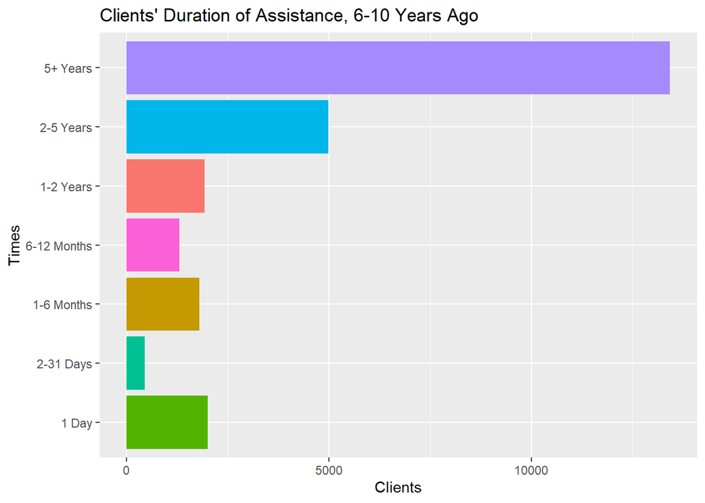

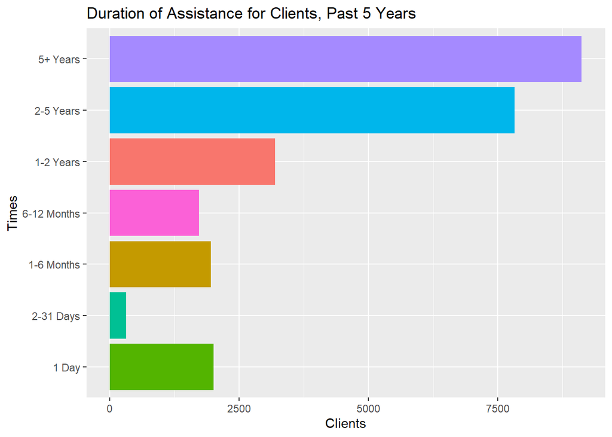

By comparing these duration groups with regard to other data, we can hope to find any possible patterns.

First, let us look at Food Pounds Per Visit for clients with different durations of assistance.

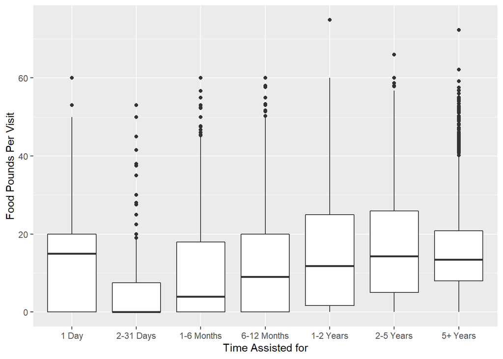

```r
ggplot(data=filter(UMD.20yr,`Food Pounds Per Visit`<75),
       aes(x=`Time Assisted for`,y=`Food Pounds Per Visit`))+
  geom_boxplot()+
  scale_x_discrete(limit=dur.group.order)
```

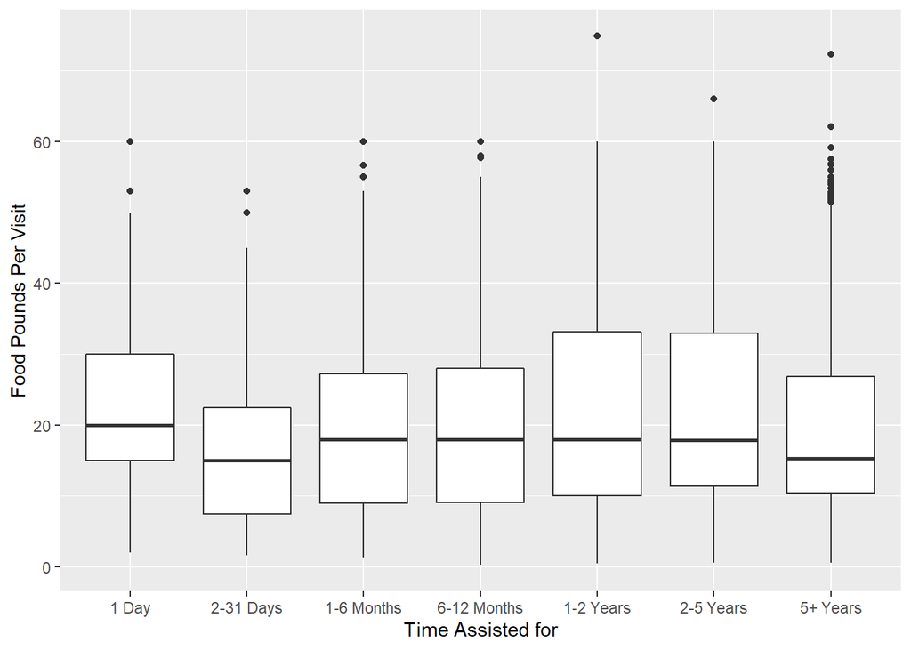

```r
ggplot(data=filter(UMD.10yr,`Food Pounds Per Visit`<75 & `Food Pounds Per Visit` >0),
       aes(x=`Time Assisted for`,y=`Food Pounds Per Visit`))+
  geom_boxplot()+
  scale_x_discrete(limit=dur.group.order)
```

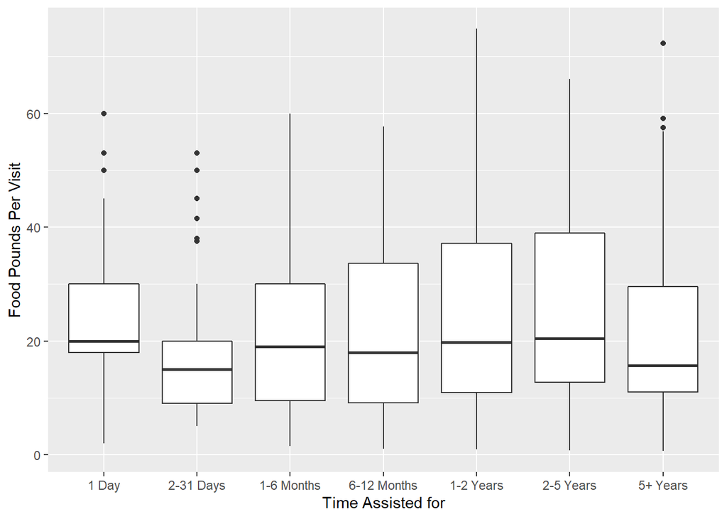

```r
ggplot(data=filter(UMD.5yr,`Food Pounds Per Visit`<75 & `Food Pounds Per Visit`>0),aes(x=`Time Assisted for`,
              y=`Food Pounds Per Visit`))+geom_boxplot()+scale_x_discrete(limit=dur.group.order)
```

One thing I notice is that the 1-day clients appear to receive slightly more food per visit than others.

This could possibly suggest that clients who receive enough food on their first visit are less likely to need to return again. Alternatively, it could instead only be due to scarcity of resources that makes it difficult to give large amounts of food to clients over long periods of time. More analysis would be required to try to help answer this question.

Next, we look at similar boxplots with regard to clothing received per visit.

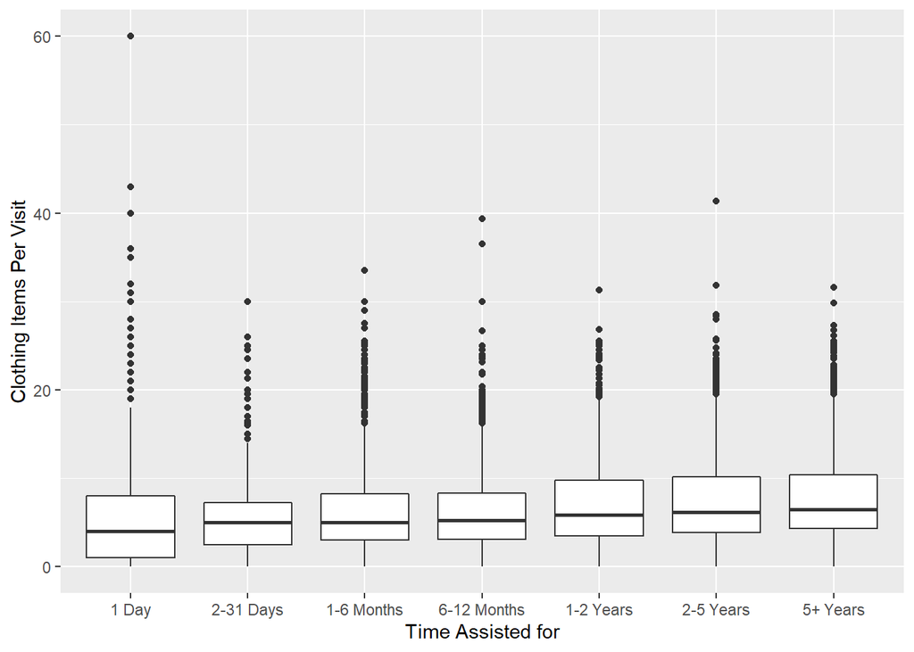

```r
ggplot(data=UMD.20yr,aes(x=`Time Assisted for`,
    y=`Clothing Items Per Visit`))+geom_boxplot()+
  scale_x_discrete(limit=dur.group.order)
```

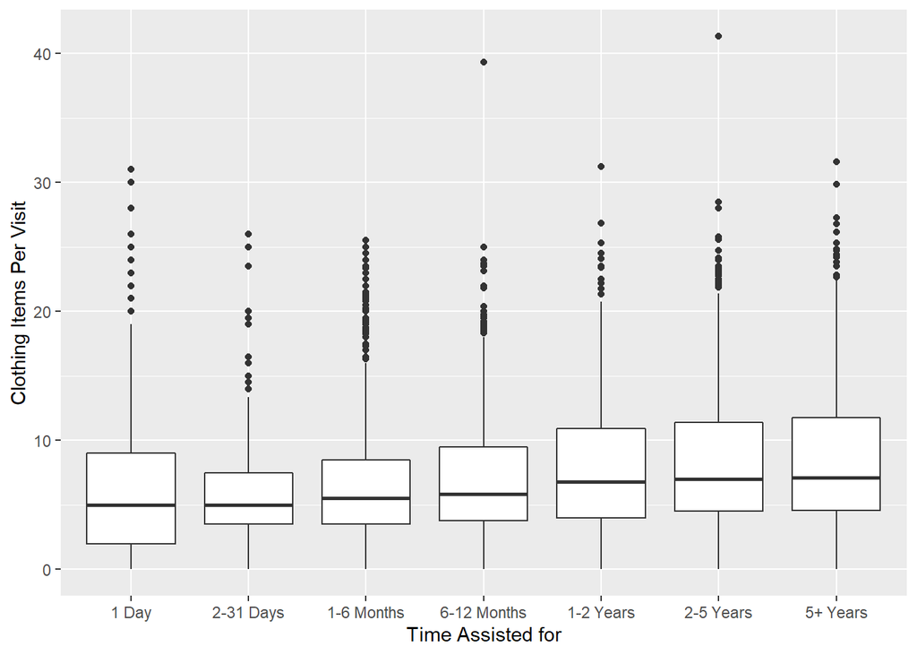

```r
ggplot(data=UMD.10yr,aes(x=`Time Assisted for`,
    y=`Clothing Items Per Visit`))+geom_boxplot()+
  scale_x_discrete(limit=dur.group.order)
```

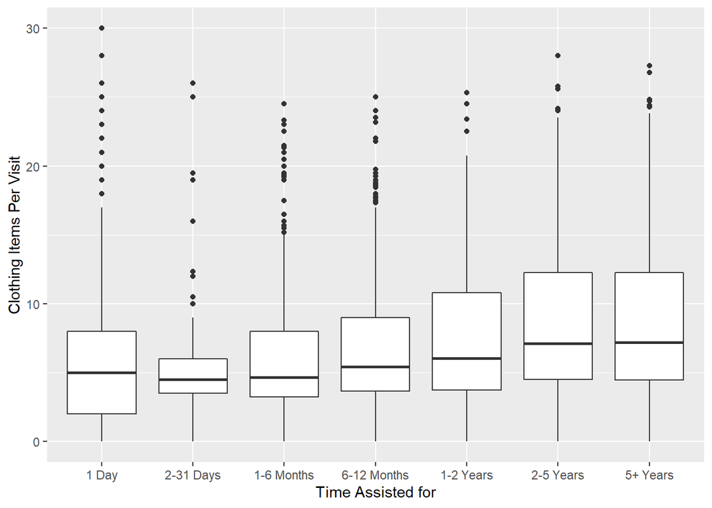

```r
ggplot(data=UMD.5yr,aes(x=`Time Assisted for`,
        y=`Clothing Items Per Visit`))+geom_boxplot()+scale_x_discrete(limit=dur.group.order)
```

Finally, we can look at direct financial support per visit.

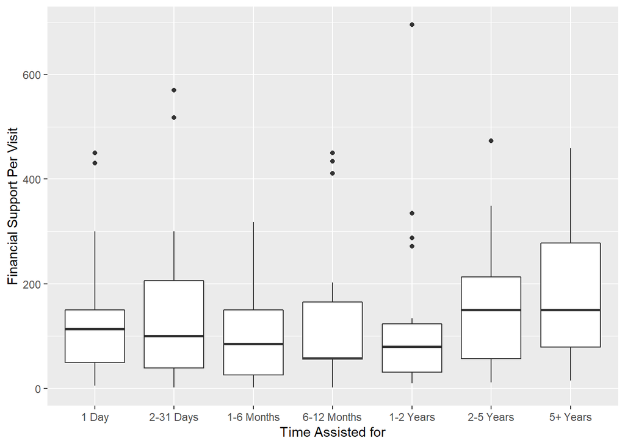

```r
ggplot(data=filter(UMD.20yr,`Financial Support Per Visit`!=0),aes(x=`Time Assisted for`,
 y=`Financial Support Per Visit`))+geom_boxplot()+scale_x_discrete(limit=dur.group.order)
```

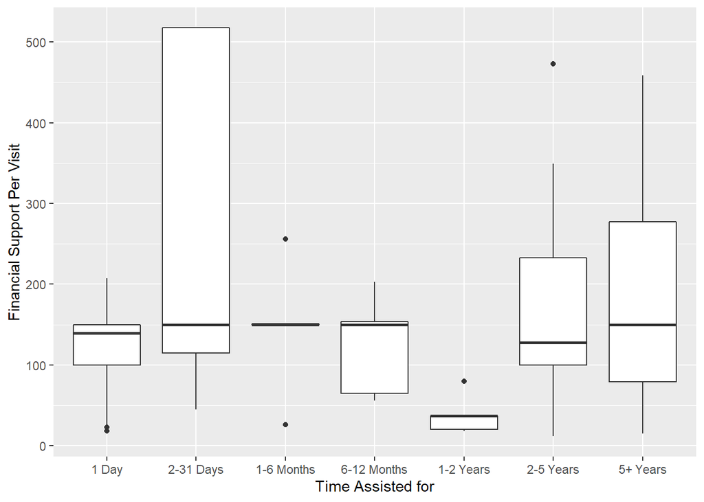

```r
ggplot(data=filter(UMD.15yr,`Financial Support Per Visit`!=0),aes(x=`Time Assisted for`,
 y=`Financial Support Per Visit`))+geom_boxplot()+scale_x_discrete(limit=dur.group.order)
```

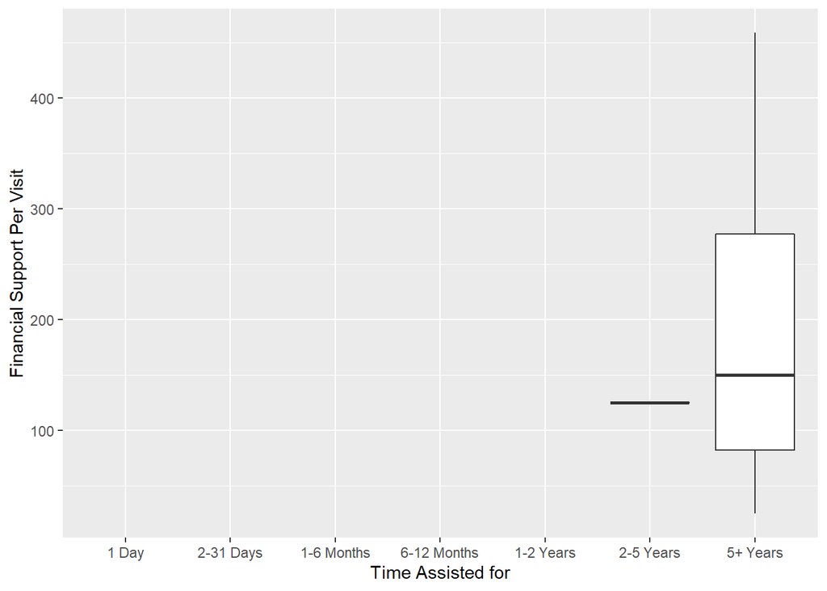

```r
ggplot(data=filter(UMD.10yr,`Financial Support Per Visit`!=0),aes(x=`Time Assisted for`,
  y=`Financial Support Per Visit`))+geom_boxplot()+scale_x_discrete(limit=dur.group.order)
```

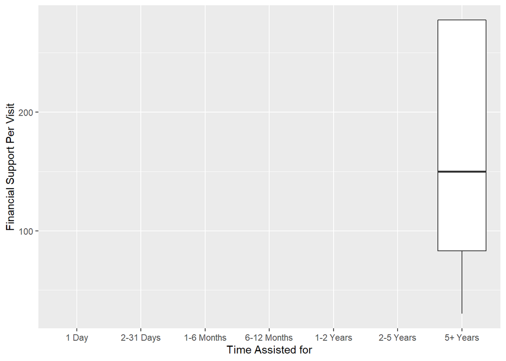

```r
ggplot(data=filter(UMD.5yr,`Financial Support Per Visit`!=0),aes(x=`Time Assisted for`,
  y=`Financial Support Per Visit`))+geom_boxplot()+scale_x_discrete(limit=dur.group.order)
```

Here, there are also not many noticeable patterns, other than the fact that direct financial support appears to have dried up over the past ten years.

At this point, I feel it would be helpful to speak directly with our clients at Urban Ministries to see how they feel about the information we have reviewed so far. Further analysis is definitely required to be able to draw many worthwhile conclusions, and it would be helpful to hear from them what directions they would like to go in.